# Do Men Tip More Than Females?

Natasha Leodjaja

May 29, 2022

### Abstract

Do you tip when you go eat in restaurants? If so, how do you determine the amount of tip to give? Does size party influences the tip amount? Bigger parties tip more? Do females tip more than men? A lot of people such as Economists have a hard time to solve this issue or explain this problem. This study investigates factors that influence tip amounts in the service industry such as gender, party size and day of the week. It was first tested by a two sample t-test to compare the means of tip given by male and females. Then I build a model using Multivariate linear model, the model can make decent predictions about the response, which can be used to predict tip amount and make rough speculations about tipping in real life.

### Introduction

Growing up in Indonesia, I have never once tipped our food servers and I was curious to see how much do waiters/waitress in the US earn by serving a party. In the US, tipping is an understood necessity of the service industry to balance out the standard server wage of approximately $2.13 an hour. With so many individuals working in the service industry and making a living, it is estimated that billions of dollars are spent on tipping each year (Nelson 2017). The dataset used for this study was collected by the food server of a restaurant. The goal of this study or analysis is to evaluate whether certain factors such as gender, day of the week and party size contribute in determining the amount of tip that food servers get.

In this study, we will be evaluating said factors and use the tips dataset to test out two hypotheses. I hypothesize that the average tip given by men is equal to the average tip given by females. I also hypothesize that days, gender and group size are not a significant predictor of tip that waitress/waiters earn. This study attempted to build a multivariate linear model which allows us to see which variables affect the tip amount the most.

There’s about 244 rows in this dataset with 7 variables. However, in this study, we will only be focusing on 4 variables that is tip, sex, day and size. Where tip is our outcome of interest and the rest are our inputs of interests.

Tips Dataset

| sex | day | size | log_tip |
| --- | --- | --- | --- |
| Female | Sun | 2 | 0.0099503 |
| Male | Sun | 3 | 0.5068176 |
| Male | Sun | 3 | 1.2527630 |
| Male | Sun | 2 | 1.1969482 |
| Female | Sun | 4 | 1.2837078 |

### Exploratory Data Analysis

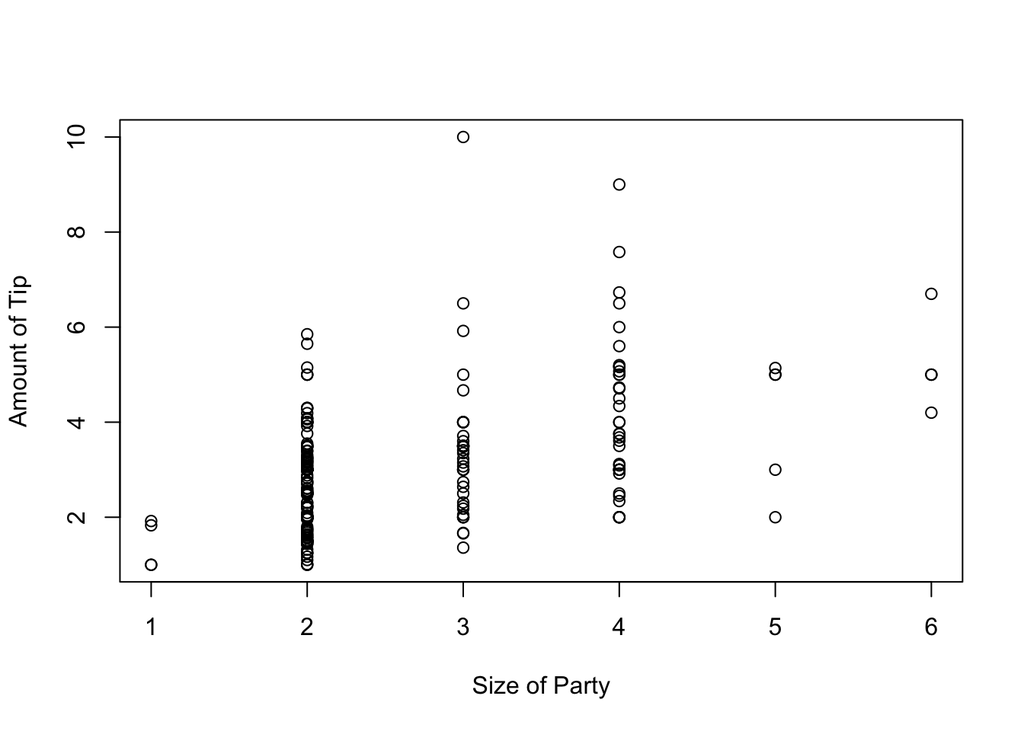

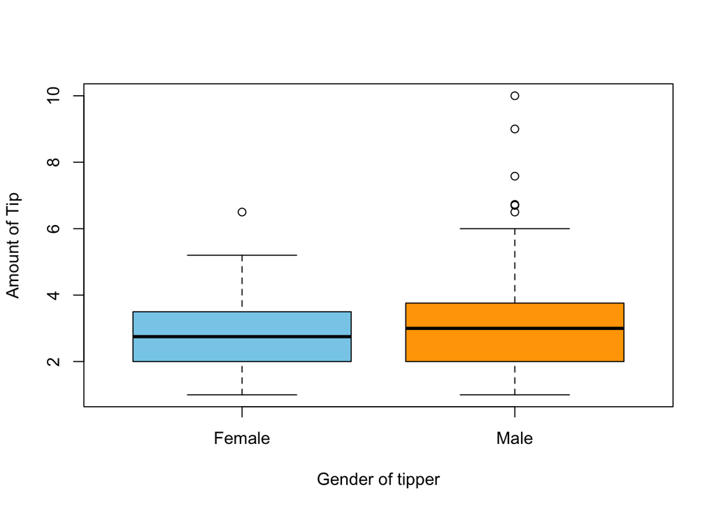

Based on the boxplot above, it seems that both females and male tips tips the same amount with an average of $3. However, looking at the male section, we can definitely see there’s several outliers where they tip very generously compared to females.

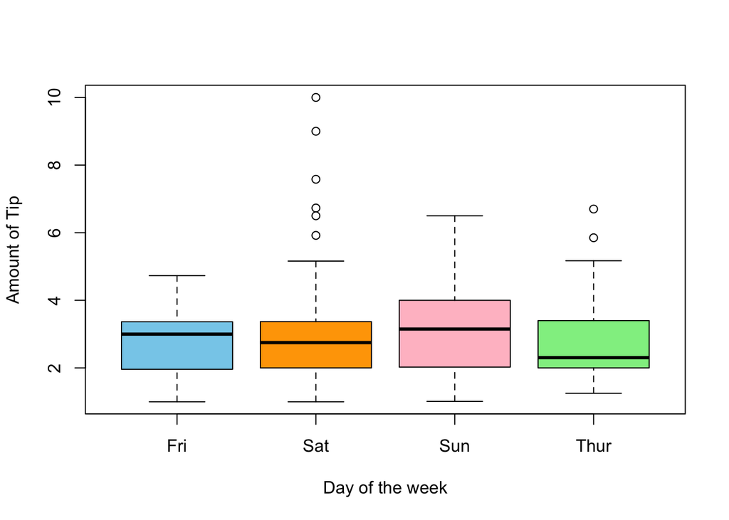

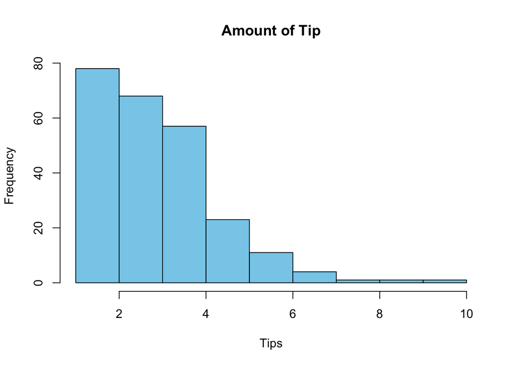

### Statistical Methods

In this study, a Two Sample T-test table is used to compare the means of tip by men and female. Multivariate Linear regression model is used for the second test to find the best fit that would best predict the tip amount. A significance value of 0.05 is used in statistical tests.

The two-sample t-test compares whether the means of two groups are significantly different from each other. This test has the following assumptions: assumes that the observations from each group represent a random sample from the population, assumes that the observations follow a normal distribution, assumes that the observations from the two groups have the same variance. If we have two groups called group 1 and group 2, the two-sided hypothes for the two-sample t-test are:

$$H_0 : \mu_1 = \mu_2$$
$$H_A : \mu_1 \neq \mu_2$$

Before we can test these hypotheses we need to ensure that our assumptions are met. We can test the normality assumption using Shapiro Wilk test. To test the homogeneity (equal) of variance assumption we will use something called Levene’s Test. The null hypothesis of the Levene’s test is that the variance between the two groups are equal. The alternative hypothesis is that they are not equal. If we fail to reject the null hypothesis of the Levene’s test we can pool our variances and use a standard two-sample t-test. (Lab 4).

A multivariate linear model is built to predict the tip amount. The general form of a multivariate linear model is: $Y_i = \beta_0 + \beta_1X_i + \epsilon_i$. $Y_i$ is the response variable, and $X_i$ are predictor variables. Because it is hard to explain the whole pattern in the response variable $Y_i$, combinations of explanatory variables $X_i$ are used to predict the response variable. The assumptions for a general linear model are samples are randomly collected, no collinearity between predictors, some linear relationship between predictors and the response variable, normal and equal variance.

$H_0:$ The average log tip amount given by male is equal to the average log tip amount given by females.  
$H_A:$ The average log tip amount given by male is not equal to the average log tip amount given by females.

#### Multivariate Linear Model: Predicting tip amount

Three linear regression models were built in order to determine which variables plays a part in predicting the best tip amount. All 3 models, model 1 (log_tip ~ Sex), model 2 (log_tip ~ Sex + day), model 3 (log_tip ~ Sex + day + size) met the normality assumption based on the Q-Qplot. Looking at the Q-Q plot, it seems that not a lot of points deviate from the straight line, the central limit theorem can be applied to conclude that sample data size is large enough so the residuals are normal. All 3 models have no distinct pattern in the residuals at the 0 line in the Residuals vs Fitted plot. Therefore, the assumption of equal variance is met.

#### Performance of the Multivariate Linear Model

Once the best model has been selected, the model fit is assessed by testing the performance of the trained data on the test data. The data is divided into train set and test set. The test set has fewer than 10% of total data so it is set to be 15 observations. Then, the model is fitted using the train set and this fitted model is used to predict values of the test set. A scatter plot is used to visualize the best model’s performance.

### Results

#### Two Sample T-Test

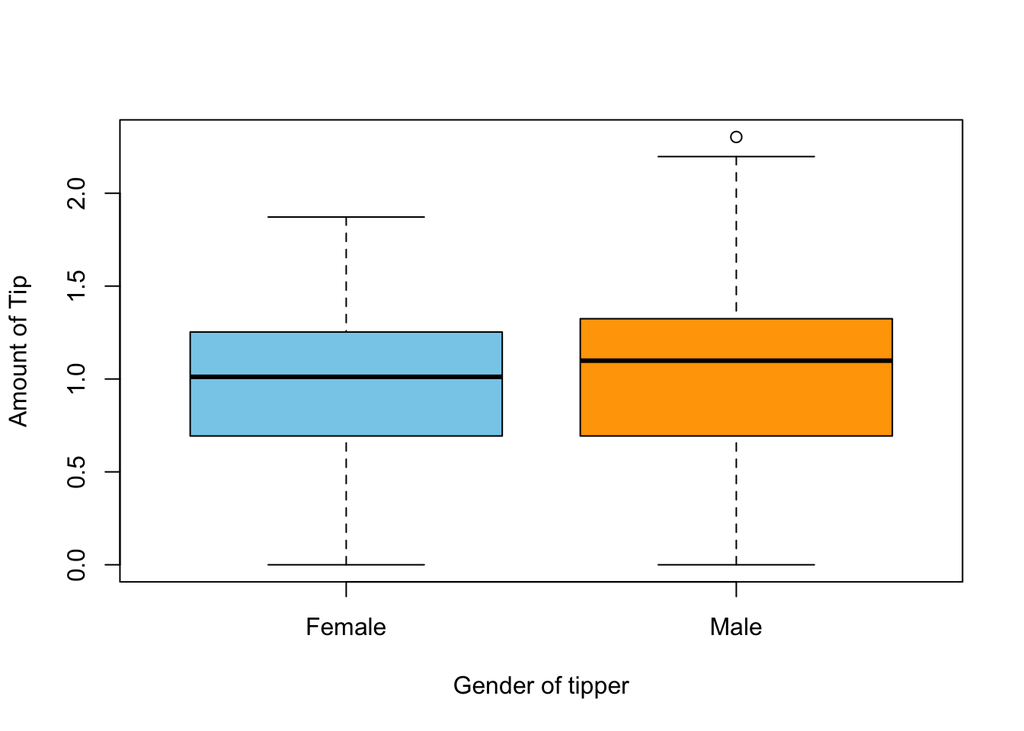

[output not shown]

#### Best Multivariate Linear model: fit3_tip

Looking at the table below, fit 3 has the lowest AIC, BIC values with the highest $R^2$ and adjusted $R^2$ values. Therefore, fit 3 is the best model for this study.

|  | df | AIC | BIC | rsq | adj_rsq |
| --- | --- | --- | --- | --- | --- |
| fit1_tip | 3 | 290.97 | 301.46 | 0.01 | 0.00 |
| fit2_tip | 6 | 291.24 | 312.22 | 0.03 | 0.01 |
| fit3_tip | 7 | 234.00 | 258.48 | 0.24 | 0.22 |

```
##
## Call:
## lm(formula = log_tip ~ sex + day + size, data = tips)
##
## Residuals:
##      Min       1Q   Median       3Q      Max
## -0.89671 -0.23652  0.00908  0.25076  1.21291
##
## Coefficients:
##              Estimate Std. Error t value Pr(>|t|)
## (Intercept)  0.465943   0.107484   4.335 2.15e-05 ***
## sexMale      0.023831   0.052910   0.450    0.653
## daySat      -0.046257   0.098283  -0.471    0.638
## daySun       0.009126   0.101231   0.090    0.928
## dayThur     -0.073025   0.101294  -0.721    0.472
## size         0.215385   0.026632   8.087 3.11e-14 ***
## ---
## Signif. codes:  0 '***' 0.001 '**' 0.01 '*' 0.05 '.' 0.1 ' ' 1
##
## Residual standard error: 0.3846 on 238 degrees of freedom
## Multiple R-squared:  0.2386, Adjusted R-squared:  0.2226
## F-statistic: 14.92 on 5 and 238 DF,  p-value: 9.765e-13
```

From the summary, we can see that size of the party has p-values that are smaller than 0.05. Meaning that said variable plays a significant role in predicting tip amount. The multivariate linear model can be written in the following general form $Y = \beta_0 + \beta_1X_1 + \beta_2X_2 + \beta_3X_3 + \beta_4X_4 + \beta_5X_5 + \epsilon_i$ or $\text{log_tip} = 0.4659 + 0.0238(\text{sexMale}) - 0.0463(\text{daySat}) + 0.0091(\text{daySun}) - 0.0730( \text{dayThur}) + 0.2154(\text{size}) + \epsilon_i$.

#### Prediction of Best model: fit3_tip

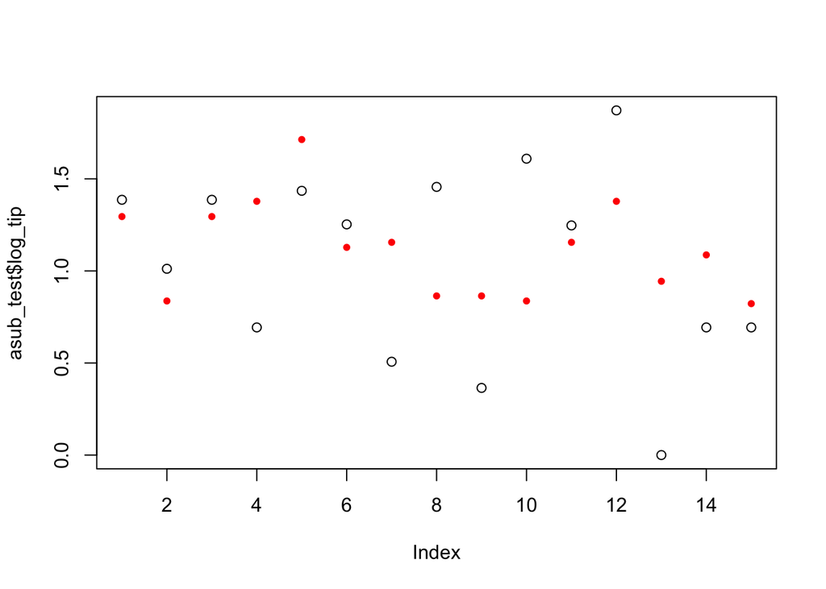

### Discussion

#### Real Life applications

Realistically speaking, there is no definitive way in predicting the amount of tip that a person would give. It could depend on the mood of the person that day. Is he/she feeling generous? are they strapped in cash? Or are they just following the 15% 18% tipping rule? We will never know.

### Future Work

Future research in regard to patron’s age or age range could greatly expand the collective understanding of tipping. While age range is an exceptionally subjective variable, it is in the authors opinion as an experienced server that someone’s tentative age can be a very telling characteristic for how you, as a server, will be treated as well as tipped. Understanding the limitations of the variable is to be noted; however it should not be overlooked (Nelson 2017). On top of that, data that was used on this study may be biased. Data was collected by a single food server at a certain restaurant. Meaning this data does not represent a majority of the tips received by food servers. In other words, the data collected was not random and could be biased.

### References

Azar O. H. (2005). “Who do we tip and why? An empirical investigation”, Applied Economics, Vol. 37, No. 16, pp. 1871-1879.  
Azar O. H. (2007). “The social norm of tipping: A review”, Journal of Applied Social Psychology, Vol. 37, No. 2, pp. 380-402.  
Conlin T. (2003). “The norm of restaurant tipping”, Journal of Economic Behavior & Organization, Vol. 52, No. 3, pp. 297-321.  
Lynn M. (1997). “Tipping customs and status seeking: A crosscountry study”, International Journal of Hospitality Management, Vol. 16, pp. 221-224.  
Lynn M., Zinkhan G. M. and Harris J. (1993). “Consumer tipping: A crosscountry study”, Journal of Consumer Research, Vol. 20, pp. 478-488.  
Nelson, M. (2017). A case study in tipping: An economic anomaly. Crossing Borders: A Multidisciplinary Journal of Undergraduate Scholarship, 2(1). https://doi.org/10.4148/2373-0978.1021  
Popa, Monica, and Shayne Hurd. (2016). “The impact of sexual orientation on consumers’ tipping behavior.” Journal of Business and Economics 7.1: 94-104.

#### Appendix

```r
# library
library(kableExtra)
library(ggplot2)
library(car)
library(dplyr)
library(knitr)
library(psych)
library(tidyverse)

# sets worki# sets working directory
setwd('~/Desktop/EEMB 146')
# load data
tips <- read.csv('tips.csv')

# checks dimension of data
dim(tips) # 244 rows and 7 columns
```

```
## [1] 244   7
```

```r
str(tips) # 7 variables
```

```
## 'data.frame':    244 obs. of  7 variables:
##  $ total_bill: num  17 10.3 21 23.7 24.6 ...
##  $ tip       : num  1.01 1.66 3.5 3.31 3.61 4.71 2 3.12 1.96 3.23 ...
##  $ sex       : chr  "Female" "Male" "Male" "Male" ...
##  $ smoker    : chr  "No" "No" "No" "No" ...
##  $ day       : chr  "Sun" "Sun" "Sun" "Sun" ...
##  $ time      : chr  "Dinner" "Dinner" "Dinner" "Dinner" ...
##  $ size      : int  2 3 3 2 4 4 2 4 2 2 ...
```

```r
summary(tips)
```

```
##    total_bill         tip             sex               smoker
##  Min.   : 3.07   Min.   : 1.000   Length:244         Length:244
##  1st Qu.:13.35   1st Qu.: 2.000   Class :character   Class :character
##  Median :17.80   Median : 2.900   Mode  :character   Mode  :character
##  Mean   :19.79   Mean   : 2.998
##  3rd Qu.:24.13   3rd Qu.: 3.562
##  Max.   :50.81   Max.   :10.000
##      day                time                size
##  Length:244         Length:244         Min.   :1.00
##  Class :character   Class :character   1st Qu.:2.00
##  Mode  :character   Mode  :character   Median :2.00
##                                        Mean   :2.57
##                                        3rd Qu.:3.00
##                                        Max.   :6.00
```

```r
# check if there's any NA values
sum(is.na(tips)) # 0
```

```
## [1] 0
```

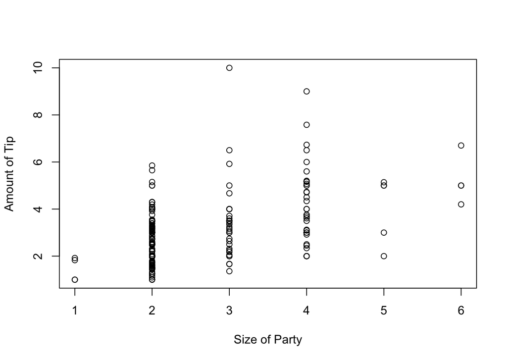

```r
# using the select function to pull specific columns into a NEW dataframe
tips <- tips %>%
    select(tip, sex, day, size)

# scatterplot
plot(tip ~ size, data = tips, xlab='Size of Party', ylab='Amount of Tip')
```

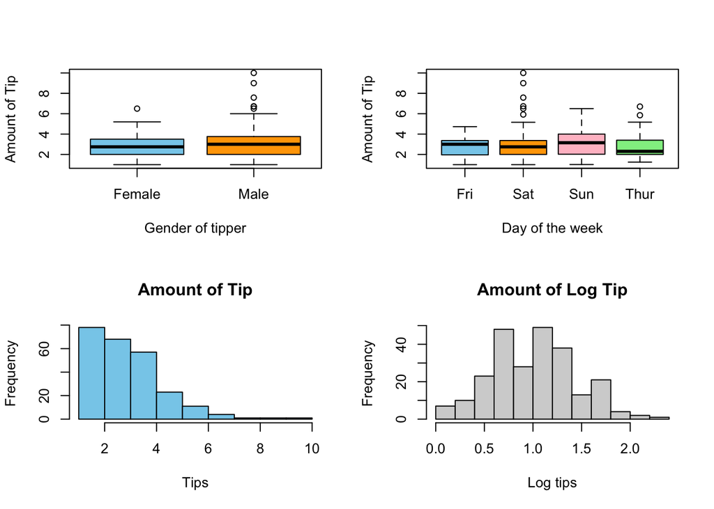

```r
par(mfrow=c(2,2))

# boxplot
boxplot(tip ~ sex, data = tips, xlab='Gender of tipper', ylab='Amount of Tip',
        col = c('Sky Blue', 'Orange'))

# boxplot
boxplot(tip ~ day, data = tips, xlab='Day of the week', ylab='Amount of Tip',
        col = c('Sky Blue', 'Orange', 'Pink', 'Light Green'))

# histogram to check normality of our Y variable
hist(tips$tip, xlab='Tips', main='Amount of Tip', col=c('Sky Blue'))

# Y variable is right skewed and not symmetrical.
# Meaning it's not normally distributed.

# log transformation
tips$log_tip <- log(tips$tip)
hist(tips$log_tip, xlab='Log tips', main='Amount of Log Tip')
```

```r
# data looks normal after log transformation

par(mfrow=c(1,1))

# Shapiro-Wilks test
shapiro.test(tips$log_tip) # p value = 0.05621 > 0.05, failed to reject null hypothesis
```

```
##
##  Shapiro-Wilk normality test
##
## data:  tips$log_tip
## W = 0.98885, p-value = 0.05621
```

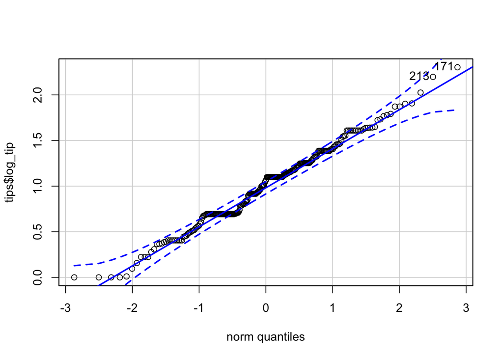

```
## [1] 171 213
```

```r
# data is normal
# qqPlot
qqPlot(tips$log_tip) # Y variable looks normally distributed
```

```r
# FIRST TEST
# Two Sample T-test to compare means
# include log transformed tip
tips <- tips %>%
    select(sex, day, size, log_tip)

# subset data to males and females
male <- subset(tips, tips$sex == "Male")
female <- subset(tips, tips$sex == "Female")

# randomly sample data
male <- sample_n(male, 80)
female <- sample_n(female, 80)

# shapiro test
shapiro.test(male$log_tip) # > 0.05
```

```
##
##  Shapiro-Wilk normality test
##
## data:  male$log_tip
## W = 0.97186, p-value = 0.07454
```